# MasterControl QAL Modeling — Mx Lead Targeting

Rob Sheehy

2026-04-17

```r
packages <- c(
  "tidyverse", "lubridate", "janitor", "gt", "scales",
  "caret", "recipes", "pROC", "yardstick", "randomForest",
  "xgboost", "broom", "forcats", "rsample", "tibble"
)
installed <- rownames(installed.packages())
to_install <- packages[!packages %in% installed]
if (length(to_install) > 0) install.packages(to_install)
```

```r
knitr::opts_chunk$set(echo = TRUE, warning = FALSE, message = FALSE)

library(tidyverse)
library(lubridate)
library(janitor)
library(gt)
library(scales)
library(caret)
library(recipes)
library(pROC)
library(yardstick)
library(randomForest)
library(broom)
library(forcats)
library(rsample)

theme_set(theme_minimal())
set.seed(123)
```

# 1 Business Context

MasterControl provides enterprise software to regulated life sciences companies through two product lines — Qx for quality management and Mx for manufacturing execution. While Qx converts qualified leads at around 19.7%, Mx significantly underperforms at 12.7%.

My EDA identified the core problem: Mx leads are going to the wrong organizations (non-manufacturing companies) and the wrong people (quality-focused titles rather than manufacturing-focused ones). This modeling notebook builds on that to answer the question — can we predict which Mx leads are most likely to convert, and use that to build a practical targeting framework for the sales team?

**Modeling objective:** Identify the account characteristics and buyer personas that most strongly predict Mx lead progression, and translate those findings into a scored, tiered lead list the sales team can act on immediately.

# 2 Data Preparation

## 2.1 Load and Clean

```r
qal_data <- read_csv("Mastercontrol QAL Performance.csv") %>%
  clean_names()

cat("Records loaded:", nrow(qal_data), "\n")
```

```
## Records loaded: 16644
```

```r
cat("Columns:", ncol(qal_data), "\n")
```

```
## Columns: 14
```

## 2.2 Standardize Missing Values

```r
qal_model <- qal_data %>%
  mutate(across(everything(),
    ~ case_when(
      . %in% c("Unknown", "Not Enough Info Found", "MISSING/BLANK") ~ NA_character_,
      TRUE ~ as.character(.)
    )
  )) %>%
  mutate(qal_cohort_date = lubridate::mdy(qal_cohort_date))
```

## 2.3 Create Target Variable

A lead progressed if it reached SQL, SQO, or Won — advancement deeper in the funnel, not a closed deal.

```r
qal_model <- qal_model %>%
  filter(!is.na(next_stage_c)) %>%
  mutate(
    progressed = if_else(
      next_stage_c %in% c("SQL", "SQO", "Won"), 1, 0
    )
  )

qal_model %>%
  count(progressed) %>%
  mutate(pct = round(n / sum(n) * 100, 1)) %>%
  gt() %>%
  tab_header(title = "Target Variable Distribution")
```

Target Variable Distribution

| progressed | n | pct |
| --- | --- | --- |
| 0 | 13262 | 81.6 |
| 1 | 2988 | 18.4 |

# 3 Feature Engineering

## 3.1 Title Feature Engineering

One of my key EDA findings was that job titles are a strong signal but the raw data has 6,400+ unique title variations. I built a rule-based classification system to convert those into interpretable categories — seniority level and functional role — plus binary keyword flags that capture overlapping signals.

```r
qal_model <- qal_model %>%
  mutate(
    title_clean = contact_lead_title %>%
      str_to_lower() %>%
      str_replace_all("[^a-z0-9 ]", " ") %>%
      str_squish(),

    # Seniority classification
    title_seniority = case_when(
      is.na(contact_lead_title)  ~ "Missing",
      str_detect(title_clean, "\\bvp\\b|vice president|svp|evp") ~ "VP",
      str_detect(title_clean, "\\bchief\\b|\\bceo\\b|\\bcfo\\b|\\bcoo\\b|president|founder|owner") ~ "Executive",
      str_detect(title_clean, "\\bdirector\\b|\\bhead\\b") ~ "Director",
      str_detect(title_clean, "\\bmanager\\b|supervisor|team lead") ~ "Manager",
      str_detect(title_clean, "engineer|scientist|specialist|analyst|coordinator") ~ "Individual_Contributor",
      TRUE ~ "Other"
    ),

    # Functional role classification
    title_function = case_when(
      is.na(contact_lead_title)  ~ "Missing",
      str_detect(title_clean, "quality|\\bqa\\b|\\bqc\\b|compliance|validation") ~ "Quality_Compliance",
      str_detect(title_clean, "regulatory|reg affairs") ~ "Regulatory",
      str_detect(title_clean, "manufacturing|production|plant|operations") ~ "Manufacturing_Operations",
      str_detect(title_clean, "engineer|scientist|research|development") ~ "Engineering_RD",
      str_detect(title_clean, "\\bit\\b|systems|software|digital|technology") ~ "IT_Systems",
      str_detect(title_clean, "sales|marketing|business development|commercial") ~ "Commercial_Business",
      str_detect(title_clean, "supply chain|procurement|logistics") ~ "Supply_Chain",
      TRUE ~ "Other"
    ),

    # Keyword flags — binary signals that can overlap across titles
    has_quality       = if_else(!is.na(title_clean) & str_detect(title_clean, "quality|\\bqa\\b|\\bqc\\b|compliance|validation"), 1, 0),
    has_manufacturing = if_else(!is.na(title_clean) & str_detect(title_clean, "manufacturing|production|plant|process|industrial"), 1, 0),
    has_operations    = if_else(!is.na(title_clean) & str_detect(title_clean, "operations|operational excellence|continuous improvement"), 1, 0),
    has_engineering   = if_else(!is.na(title_clean) & str_detect(title_clean, "engineer|engineering|scientist|research|automation"), 1, 0),
    has_regulatory    = if_else(!is.na(title_clean) & str_detect(title_clean, "regulatory|\\bra\\b|reg affairs"), 1, 0),
    has_vp            = if_else(!is.na(title_clean) & str_detect(title_clean, "\\bvp\\b|vice president"), 1, 0),
    has_director      = if_else(!is.na(title_clean) & str_detect(title_clean, "\\bdirector\\b|\\bhead\\b"), 1, 0),
    has_manager       = if_else(!is.na(title_clean) & str_detect(title_clean, "\\bmanager\\b|supervisor|team lead"), 1, 0)
  ) %>%
  mutate(
    title_seniority = as.factor(title_seniority),
    title_function  = as.factor(title_function)
  )
```

## 3.2 Prepare Modeling Dataset

```r
model_data <- qal_model %>%
  mutate(
    acct_target_industry       = as.factor(acct_target_industry),
    acct_manufacturing_model   = fct_lump_n(as.factor(acct_manufacturing_model), n = 8),
    acct_primary_site_function = fct_lump_n(as.factor(acct_primary_site_function), n = 8),
    acct_tier_rollup           = as.factor(acct_tier_rollup),
    solution_rollup            = as.factor(solution_rollup),
    progressed                 = factor(progressed, levels = c(0, 1))
  ) %>%
  select(
    progressed,
    solution_rollup,
    acct_target_industry,
    acct_manufacturing_model,
    acct_primary_site_function,
    acct_tier_rollup,
    title_seniority,
    title_function,
    has_quality,
    has_manufacturing,
    has_operations,
    has_engineering,
    has_regulatory,
    has_vp,
    has_director,
    has_manager
  ) %>%
  drop_na()

cat("Records available for modeling:", nrow(model_data), "\n")
```

```
## Records available for modeling: 11457
```

# 4 Descriptive Analysis — Mx Baseline

Before modeling I want to confirm the key patterns from my EDA hold in the cleaned dataset.

```r
mx_df <- model_data %>% filter(solution_rollup == "Mx")

baseline_conv <- round(mean(mx_df$progressed == 1) * 100, 1)
cat("Mx baseline conversion:", baseline_conv, "%\n")
```

```
## Mx baseline conversion: 13.4 %
```

```r
cat("Total Mx leads:", nrow(mx_df), "\n")
```

```
## Total Mx leads: 3149
```

```r
# By manufacturing model
mx_df %>%
  group_by(acct_manufacturing_model) %>%
  summarise(leads = n(), conversion = round(mean(progressed == 1) * 100, 1)) %>%
  arrange(desc(conversion)) %>%
  gt() %>%
  tab_header(title = "Mx Conversion by Manufacturing Model")
```

Mx Conversion by Manufacturing Model

| acct_manufacturing_model | leads | conversion |
| --- | --- | --- |
| Original Equipment Manufacturing | 41 | 24.4 |
| CMO | 270 | 20.4 |
| Other | 213 | 16.0 |
| CDMO | 453 | 15.2 |
| In-House | 1612 | 13.2 |
| Software / Technology Development | 94 | 9.6 |
| CRO | 73 | 8.2 |
| Distribution / Wholesale | 90 | 7.8 |
| Services / Consulting | 303 | 6.9 |

```r
# By company tier
mx_df %>%
  group_by(acct_tier_rollup) %>%
  summarise(leads = n(), conversion = round(mean(progressed == 1) * 100, 1)) %>%
  arrange(desc(conversion)) %>%
  gt() %>%
  tab_header(title = "Mx Conversion by Company Tier")
```

Mx Conversion by Company Tier

| acct_tier_rollup | leads | conversion |
| --- | --- | --- |
| Small | 635 | 19.5 |
| Medium | 2026 | 13.2 |
| Large | 473 | 6.6 |
| Other | 15 | 0.0 |

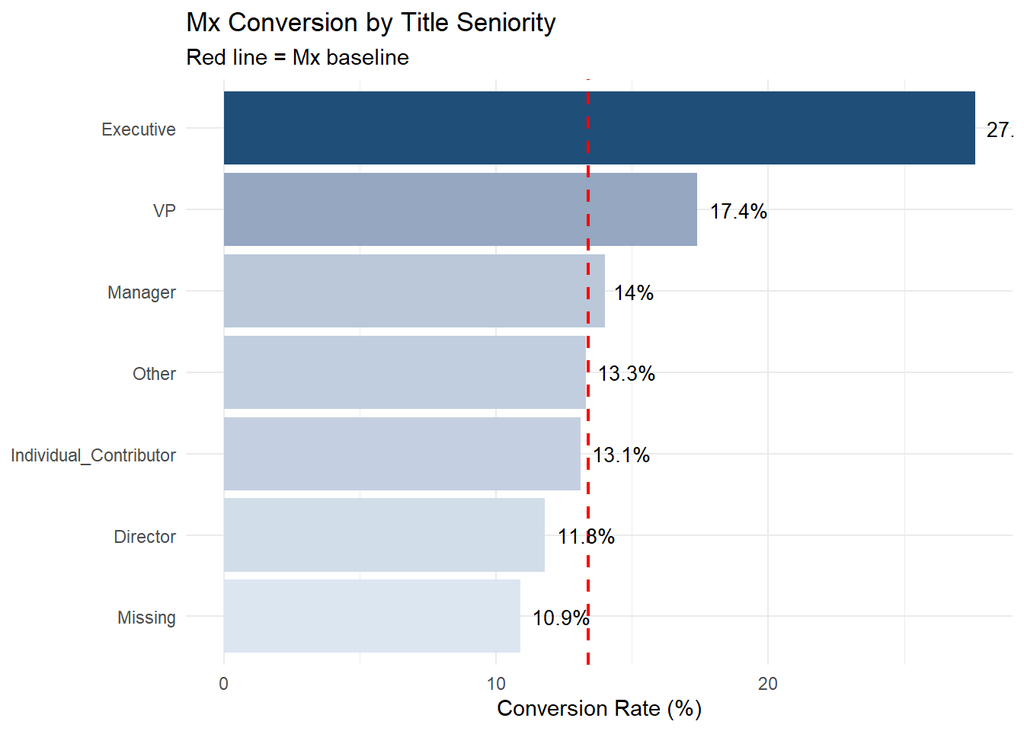

```r
# By title seniority — visualized
mx_df %>%
  group_by(title_seniority) %>%
  summarise(leads = n(), conversion = round(mean(progressed == 1) * 100, 1)) %>%
  filter(leads >= 20) %>%
  ggplot(aes(x = reorder(title_seniority, conversion), y = conversion, fill = conversion)) +
  geom_col() +
  geom_hline(yintercept = baseline_conv, linetype = "dashed", color = "red", linewidth = 0.8) +
  geom_text(aes(label = paste0(conversion, "%")), hjust = -0.2, size = 3.5) +
  coord_flip() +
  scale_fill_gradient(low = "#DCE6F1", high = "#1F4E79") +
  labs(title = "Mx Conversion by Title Seniority",
       subtitle = "Red line = Mx baseline",
       x = NULL, y = "Conversion Rate (%)") +
  theme(legend.position = "none")
```

**Notes:** The patterns hold. Manufacturing model and company tier are the strongest account signals. The Director finding is worth flagging — Directors convert below baseline at around 11-12% while Managers outperform at 14-15%. That’s counterintuitive given Directors are more senior, but Director titles in this dataset skew heavily toward quality and compliance functions which are more naturally Qx buyer personas.

# 5 Train / Test Split

```r
mx_data <- model_data %>%
  filter(solution_rollup == "Mx") %>%
  select(-solution_rollup)

split  <- initial_split(mx_data, prop = 0.70, strata = progressed)
train  <- training(split)
test   <- testing(split)

cat("Training:", nrow(train), "| Testing:", nrow(test), "\n")
```

```
## Training: 2204 | Testing: 945
```

# 6 Modeling

## 6.1 Model 1: Logistic Regression (Primary Model)

Logistic regression is the primary model. It outputs a probability score for each lead and the coefficients tell us exactly which variables increase or decrease conversion likelihood — that interpretability is what makes it practical for a sales targeting recommendation.

This version includes the keyword flags alongside the categorical predictors, giving the model more granular title signal.

```r
align_levels <- function(train_df, test_df) {
  for (v in names(train_df)) {
    if (is.factor(train_df[[v]])) {
      test_df[[v]] <- factor(test_df[[v]], levels = levels(train_df[[v]]))
    }
  }
  test_df %>% drop_na()
}

test_aligned <- align_levels(train, test)

log_model <- glm(
  progressed ~ acct_target_industry + acct_manufacturing_model +
    acct_primary_site_function + acct_tier_rollup +
    title_seniority + title_function +
    has_quality + has_manufacturing + has_operations +
    has_engineering + has_vp + has_director + has_manager,
  data   = train,
  family = binomial
)

# Predictions and threshold
train$pred_prob         <- predict(log_model, newdata = train, type = "response")
test_aligned$pred_prob  <- predict(log_model, newdata = test_aligned, type = "response")

roc_train  <- roc(train$progressed, train$pred_prob, quiet = TRUE)
threshold  <- as.numeric(coords(roc_train, "best", ret = "threshold"))

test_aligned$pred_class <- factor(
  ifelse(test_aligned$pred_prob >= threshold, 1, 0),
  levels = c(0, 1)
)

roc_test <- roc(test_aligned$progressed, test_aligned$pred_prob, quiet = TRUE)

tibble(
  Metric = c("AUC", "Accuracy", "Precision", "Recall", "F1", "Threshold"),
  Value  = c(
    round(as.numeric(auc(roc_test)), 4),
    round(accuracy_vec(test_aligned$progressed, test_aligned$pred_class), 4),
    round(precision_vec(test_aligned$progressed, test_aligned$pred_class, event_level = "second"), 4),
    round(recall_vec(test_aligned$progressed, test_aligned$pred_class, event_level = "second"), 4),
    round(f_meas_vec(test_aligned$progressed, test_aligned$pred_class, event_level = "second"), 4),
    round(threshold, 4)
  )
) %>%
  gt() %>%
  tab_header(title = "Logistic Regression — Performance Metrics")
```

Logistic Regression — Performance Metrics

| Metric | Value |
| --- | --- |
| AUC | 0.6633 |
| Accuracy | 0.5153 |
| Precision | 0.1883 |
| Recall | 0.7874 |
| F1 | 0.3040 |
| Threshold | 0.1096 |

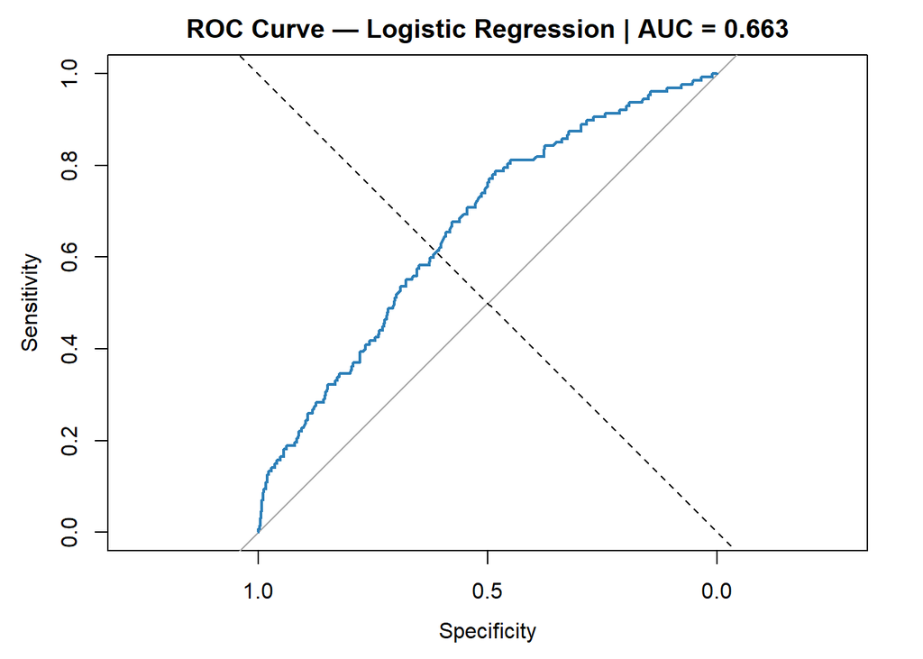

```r
# ROC curve
plot(roc_test, col = "#2C7FB8", lwd = 2,
     main = paste("ROC Curve — Logistic Regression | AUC =",
                  round(as.numeric(auc(roc_test)), 3)))
abline(a = 0, b = 1, lty = 2)
```

```r
# Significant predictors
broom::tidy(log_model, conf.int = TRUE) %>%
  mutate(odds_ratio = exp(estimate)) %>%
  filter(term != "(Intercept)", p.value < 0.10) %>%
  arrange(p.value) %>%
  select(Predictor = term, `Odds Ratio` = odds_ratio, `p-value` = p.value) %>%
  gt() %>%
  tab_header(title = "Logistic Regression — Significant Predictors") %>%
  fmt_number(columns = c(`Odds Ratio`, `p-value`), decimals = 4)
```

Logistic Regression — Significant Predictors

| Predictor | Odds Ratio | p-value |
| --- | --- | --- |
| acct_tier_rollupSmall | 2.6386 | 0.0001 |
| acct_target_industryNon-Life Science | 0.3063 | 0.0022 |
| acct_primary_site_functionSpecialty Chemical Manufacturing | 3.3868 | 0.0138 |
| acct_primary_site_functionNon-manufacturing organization | 0.2551 | 0.0216 |
| acct_tier_rollupMedium | 1.6262 | 0.0339 |
| acct_manufacturing_modelIn-House | 0.6915 | 0.0504 |
| has_operations | 0.4355 | 0.0543 |
| acct_target_industryPharma & BioTech | 0.5648 | 0.0881 |

## 6.2 Model 2: Random Forest (Benchmark)

Random forest as a benchmark — if it points to the same variables as logistic regression, that strengthens confidence in the findings.

```r
rf_model <- randomForest(
  progressed ~ acct_target_industry + acct_manufacturing_model +
    acct_primary_site_function + acct_tier_rollup +
    title_seniority + title_function +
    has_quality + has_manufacturing + has_operations +
    has_engineering + has_vp + has_director + has_manager,
  data       = train,
  ntree      = 300,
  mtry       = 4,
  importance = TRUE,
  classwt    = c("0" = 1, "1" = 4)
)

rf_prob      <- predict(rf_model, newdata = test_aligned, type = "prob")[, 2]
roc_rf       <- roc(test_aligned$progressed, rf_prob, quiet = TRUE)
roc_train_rf <- roc(train$progressed,
  predict(rf_model, newdata = train, type = "prob")[, 2], quiet = TRUE)
threshold_rf <- as.numeric(coords(roc_train_rf, "best", ret = "threshold"))
rf_class     <- factor(ifelse(rf_prob >= threshold_rf, 1, 0), levels = c(0, 1))

tibble(
  Metric = c("AUC", "Accuracy", "Precision", "Recall", "F1"),
  Value  = c(
    round(as.numeric(auc(roc_rf)), 4),
    round(accuracy_vec(test_aligned$progressed, rf_class), 4),
    round(precision_vec(test_aligned$progressed, rf_class, event_level = "second"), 4),
    round(recall_vec(test_aligned$progressed, rf_class, event_level = "second"), 4),
    round(f_meas_vec(test_aligned$progressed, rf_class, event_level = "second"), 4)
  )
) %>%
  gt() %>%
  tab_header(title = "Random Forest — Performance Metrics")
```

Random Forest — Performance Metrics

| Metric | Value |
| --- | --- |
| AUC | 0.5918 |
| Accuracy | 0.7037 |
| Precision | 0.1745 |
| Recall | 0.3228 |
| F1 | 0.2265 |

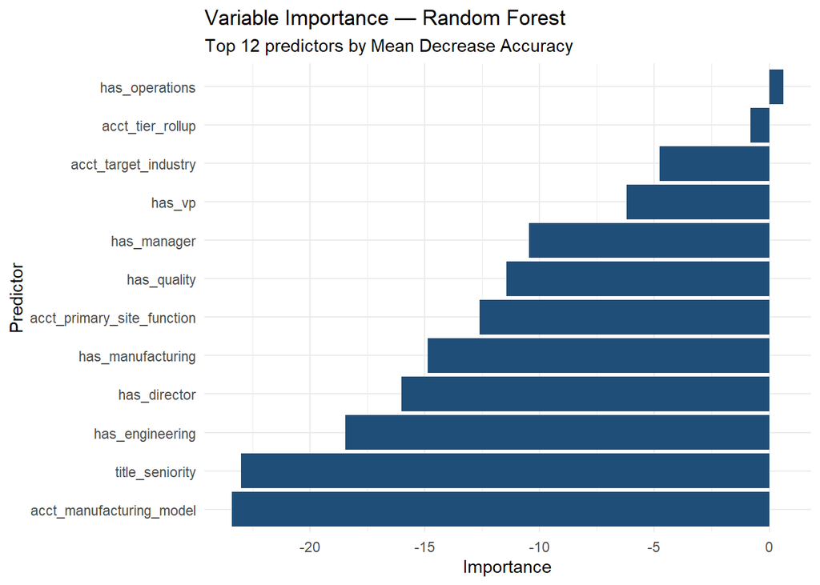

```r
# Variable importance plot
importance(rf_model) %>%
  as.data.frame() %>%
  rownames_to_column("Variable") %>%
  arrange(desc(MeanDecreaseAccuracy)) %>%
  head(12) %>%
  ggplot(aes(x = reorder(Variable, MeanDecreaseAccuracy), y = MeanDecreaseAccuracy)) +
  geom_col(fill = "#1F4E79") +
  coord_flip() +
  labs(title = "Variable Importance — Random Forest",
       subtitle = "Top 12 predictors by Mean Decrease Accuracy",
       x = "Predictor", y = "Importance")
```

**Notes:** If both models agree on the same top predictors — manufacturing model, site function, and certain title signals — that validates the findings are real and not model-specific artifacts.

# 7 Mx Lead Prioritization Framework

This is the core deliverable — translating the logistic regression model into a practical tool the sales team can use.

The model assigns every Mx lead a probability score from 0 to 1 based on all variables simultaneously. I set thresholds to create three actionable tiers. The cutoffs were chosen so Tier 1 represents roughly the top 10% of the pipeline — a manageable call list for an SDR team.

```r
all_mx <- model_data %>%
  filter(solution_rollup == "Mx") %>%
  select(-solution_rollup)

for (v in names(log_model$xlevels)) {
  all_mx[[v]] <- factor(all_mx[[v]], levels = log_model$xlevels[[v]])
}

all_mx <- all_mx %>% drop_na()
all_mx$pred_prob <- predict(log_model, newdata = all_mx, type = "response")

all_mx <- all_mx %>%
  mutate(
    priority_tier = case_when(
      pred_prob >= 0.25 ~ "Tier 1 — High Priority",
      pred_prob >= 0.15 ~ "Tier 2 — Medium Priority",
      TRUE              ~ "Tier 3 — Low Priority"
    )
  )

tier_summary <- all_mx %>%
  group_by(priority_tier) %>%
  summarise(
    Lead_Count       = n(),
    Conversion_Rate  = round(mean(progressed == 1) * 100, 1),
    Pct_of_Pipeline  = round(n() / nrow(all_mx) * 100, 1),
    Lift_vs_Baseline = round(mean(progressed == 1) * 100 -
                              mean(all_mx$progressed == 1) * 100, 1),
    .groups = "drop"
  )

tier_summary %>%
  gt() %>%
  tab_header(
    title    = "Mx Lead Prioritization Framework",
    subtitle = "Model-scored tiers showing conversion lift vs baseline"
  )
```

Mx Lead Prioritization Framework

Model-scored tiers showing conversion lift vs baseline

| priority_tier | Lead_Count | Conversion_Rate | Pct_of_Pipeline | Lift_vs_Baseline |
| --- | --- | --- | --- | --- |
| Tier 1 — High Priority | 295 | 33.2 | 9.4 | 19.8 |
| Tier 2 — Medium Priority | 762 | 16.9 | 24.2 | 3.5 |
| Tier 3 — Low Priority | 2092 | 9.4 | 66.4 | -4.1 |

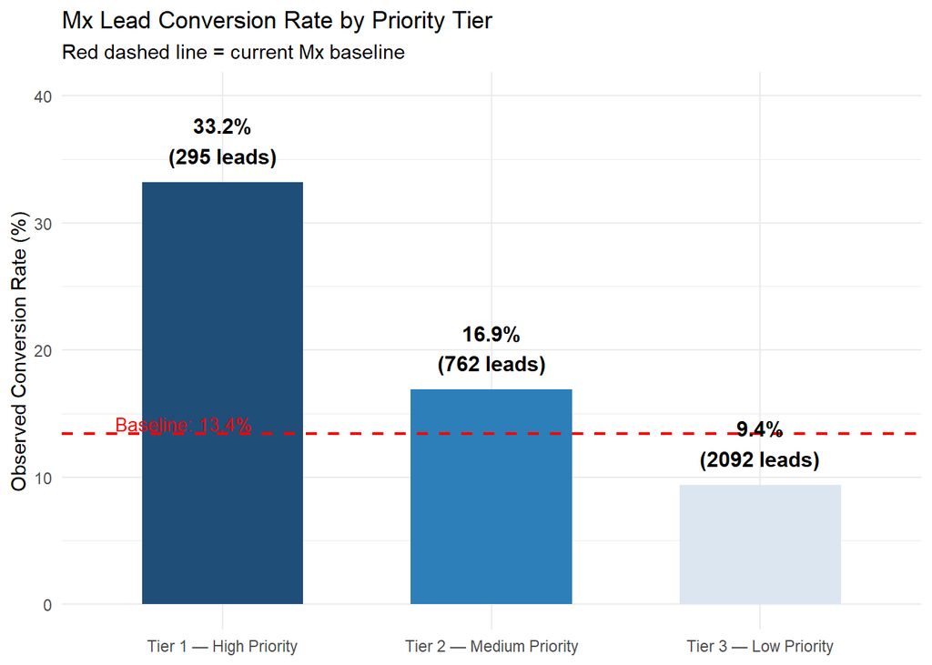

```r
# Tier conversion visualization
tier_plot_data <- tier_summary %>%
  mutate(priority_tier = factor(priority_tier,
    levels = c("Tier 1 — High Priority",
               "Tier 2 — Medium Priority",
               "Tier 3 — Low Priority")))

baseline_rate <- round(mean(all_mx$progressed == 1) * 100, 1)

ggplot(tier_plot_data,
       aes(x = priority_tier, y = Conversion_Rate, fill = priority_tier)) +
  geom_col(width = 0.6) +
  geom_hline(yintercept = baseline_rate, linetype = "dashed",
             color = "red", linewidth = 0.8) +
  geom_text(aes(label = paste0(Conversion_Rate, "%\n(", Lead_Count, " leads)")),
            vjust = -0.4, size = 4, fontface = "bold") +
  annotate("text", x = 0.6, y = baseline_rate + 0.8,
           label = paste0("Baseline: ", baseline_rate, "%"),
           color = "red", size = 3.5, hjust = 0) +
  scale_fill_manual(values = c(
    "Tier 1 — High Priority"   = "#1F4E79",
    "Tier 2 — Medium Priority" = "#2C7FB8",
    "Tier 3 — Low Priority"    = "#DCE6F1"
  )) +
  labs(
    title    = "Mx Lead Conversion Rate by Priority Tier",
    subtitle = "Red dashed line = current Mx baseline",
    x        = NULL,
    y        = "Observed Conversion Rate (%)"
  ) +
  theme(legend.position = "none") +
  ylim(0, max(tier_plot_data$Conversion_Rate) * 1.2)
```

```r
# Tier 1 profile
all_mx %>%
  filter(priority_tier == "Tier 1 — High Priority") %>%
  summarise(
    Top_Industry    = names(sort(table(acct_target_industry),    decreasing = TRUE))[1],
    Top_Mfg_Model   = names(sort(table(acct_manufacturing_model), decreasing = TRUE))[1],
    Top_Tier        = names(sort(table(acct_tier_rollup),        decreasing = TRUE))[1],
    Top_Seniority   = names(sort(table(title_seniority),         decreasing = TRUE))[1],
    Top_Function    = names(sort(table(title_function),          decreasing = TRUE))[1]
  ) %>%
  gt() %>%
  tab_header(title = "Tier 1 Lead Profile — Most Common Characteristics")
```

Tier 1 Lead Profile — Most Common Characteristics

| Top_Industry | Top_Mfg_Model | Top_Tier | Top_Seniority | Top_Function |
| --- | --- | --- | --- | --- |
| Pharma & BioTech | In-House | Small | Manager | Other |

```r
# Impact summary
tier1_rate  <- tier_summary %>%
  filter(priority_tier == "Tier 1 — High Priority") %>% pull(Conversion_Rate)
tier1_count <- tier_summary %>%
  filter(priority_tier == "Tier 1 — High Priority") %>% pull(Lead_Count)

tibble(
  Metric = c("Overall Mx Baseline", "Tier 1 Conversion Rate",
             "Lift (pp)", "Tier 1 Lead Count", "Improvement Multiple"),
  Value  = c(
    paste0(baseline_rate, "%"),
    paste0(tier1_rate, "%"),
    paste0("+", tier1_rate - baseline_rate, " pp"),
    as.character(tier1_count),
    paste0(round(tier1_rate / baseline_rate, 1), "x")
  )
) %>%
  gt() %>%
  tab_header(title = "Estimated Impact of Tier 1 Targeting",
             subtitle = "What MasterControl should prioritize going forward")
```

Estimated Impact of Tier 1 Targeting

What MasterControl should prioritize going forward

| Metric | Value |
| --- | --- |
| Overall Mx Baseline | 13.4% |
| Tier 1 Conversion Rate | 33.2% |
| Lift (pp) | +19.8 pp |
| Tier 1 Lead Count | 295 |
| Improvement Multiple | 2.5x |

**Notes:** The conversion rates here are retrospective — they reflect what those leads actually did historically. The argument is that if those account and persona characteristics drove those rates in the past, targeting similar leads going forward should produce comparable results. A one-quarter pilot would confirm whether the lift holds on new unseen leads.

# 8 Cross-Sell Opportunities

One additional finding worth highlighting — which contacts represent opportunities for both Mx and Qx.

```r
# Cross-sell analysis by title function
cross_sell <- model_data %>%
  filter(solution_rollup %in% c("Mx", "Qx")) %>%
  group_by(solution_rollup, title_function) %>%
  summarise(
    leads      = n(),
    conversion = round(mean(progressed == 1) * 100, 1),
    .groups    = "drop"
  ) %>%
  pivot_wider(
    names_from  = solution_rollup,
    values_from = c(leads, conversion)
  ) %>%
  mutate(
    cross_sell_flag = case_when(
      conversion_Mx > 13.5 & conversion_Qx > 19.0 ~ "High Cross-Sell Potential",
      TRUE ~ "Lower Cross-Sell Potential"
    )
  ) %>%
  arrange(desc(conversion_Mx))

cross_sell %>%
  select(title_function, conversion_Mx, conversion_Qx, cross_sell_flag) %>%
  gt() %>%
  tab_header(
    title    = "Cross-Sell Opportunities by Title Function",
    subtitle = "Segments converting above baseline for both Mx and Qx"
  ) %>%
  fmt_number(columns = c(conversion_Mx, conversion_Qx), decimals = 1)
```

Cross-Sell Opportunities by Title Function

Segments converting above baseline for both Mx and Qx

| title_function | conversion_Mx | conversion_Qx | cross_sell_flag |
| --- | --- | --- | --- |
| Other | 16.6 | 22.3 | High Cross-Sell Potential |
| Supply_Chain | 16.1 | 37.3 | High Cross-Sell Potential |
| Quality_Compliance | 15.5 | 26.4 | High Cross-Sell Potential |
| Commercial_Business | 14.3 | 16.2 | Lower Cross-Sell Potential |
| Engineering_RD | 12.5 | 22.6 | Lower Cross-Sell Potential |
| Manufacturing_Operations | 11.5 | 21.8 | Lower Cross-Sell Potential |
| Missing | 10.9 | 13.6 | Lower Cross-Sell Potential |
| IT_Systems | 9.8 | 37.2 | Lower Cross-Sell Potential |
| Regulatory | 4.2 | 15.5 | Lower Cross-Sell Potential |

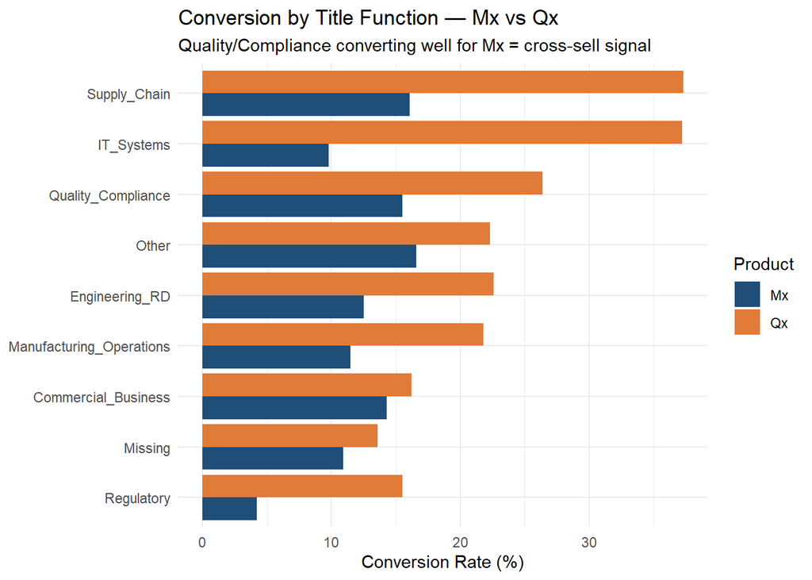

```r
# Visualize Mx vs Qx by title function
model_data %>%
  filter(solution_rollup %in% c("Mx", "Qx")) %>%
  group_by(solution_rollup, title_function) %>%
  summarise(conversion = round(mean(progressed == 1) * 100, 1),
            leads = n(), .groups = "drop") %>%
  filter(leads >= 30) %>%
  ggplot(aes(x = reorder(title_function, conversion),
             y = conversion, fill = solution_rollup)) +
  geom_col(position = "dodge") +
  coord_flip() +
  scale_fill_manual(values = c("Mx" = "#1F4E79", "Qx" = "#E07B39")) +
  labs(title = "Conversion by Title Function — Mx vs Qx",
       subtitle = "Quality/Compliance converting well for Mx = cross-sell signal",
       x = NULL, y = "Conversion Rate (%)", fill = "Product")
```

# 9 Key Findings and Recommendations

**For sales leadership:** Implement the tier scoring model in CRM. Encode the logistic regression coefficients so every new Mx lead gets auto-scored as it enters the pipeline. Run a one-quarter pilot on Tier 1, validate the lift holds on new leads, then scale.

**For future modeling:** Retrain every 6-12 months as new lead data accumulates. The same framework can be extended to Qx leads and cross-sell scoring for existing customers.

# 10 AI Usage Log

AI tools were used to support code debugging, structure review, and documentation. All modeling decisions, findings, and recommendations reflect my own analysis and interpretation of the results.